# Some illustrative examples in nonlinear statistics

# Lecture plan

Previous lecture we provides that we will continue now with the following topics:

- Probability Primer (Chapter 2) and
- Conditional Independence (Chapter 4)

## Some probability and a bit of stats

Topics:

- discrete probability distributions: basic notation.
- The model of independence.
- Limiting distributions - see section 2.3 and 2.5 in the book.

> Lecture on board.

### Topics covered in lecture 2:

- discrete and continuous random variables
- definition of a statistical model, including parameter space, implicit/explicit(parametric) description of the same model
  - two views of the same object.
- probability simplex, dimensions of the space we live in (the number of stats of discrete random varaibles dictates everything, doesn’t it?:)
- review of conditional probability, independent events, independent random variables
- Examples: the Bernoulli model, the independence model for two random variables, the model for a count of the number of heads in two coin tosses
  - explicit computation of joint probabilities,
  - a peek into implicit description - lead-in to homework 1 questions 2&3,
  - a hint as to how this might generalize to other (higher-dimensional) models.

# Why do we care about distributions?

- *Who cares* about model fitting and testing whether we have the correct model in the first place?
- Why do I have to *understand* a model?

# Simulation of a coin toss

- Let $x$ be the random variable recording the outcome of a coin toss:
  - $x_i=0$ if we see Tail on the $i$-th trial (toss),
  - $x_i=1$ if we see heads on the $i$-th trial.
- Fix $n=10000$.
- $Y$ = the number of heads.
  - Is the number of heads supposed to be $n/2$? How far off is it? Does it vary? What does this mean?

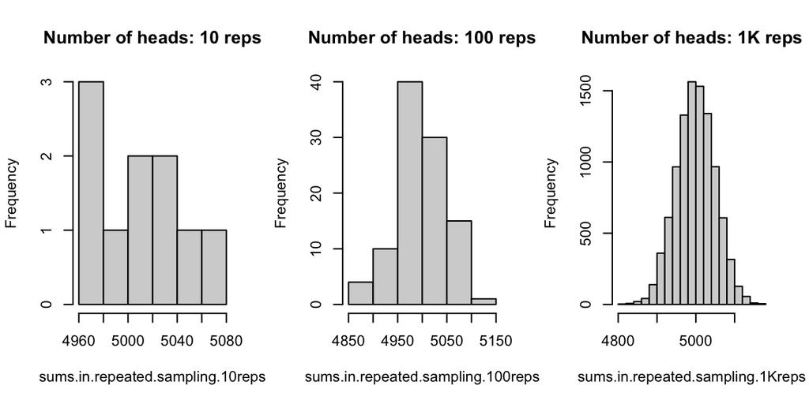

| Means of Y |
| --- |
| 5007.900 |
| 4998.540 |
| 4999.927 |

[output not shown]

#### Question:

is it possible that something similar to this always happens?

# Importance of sampling distributions

- about the model behind the data ;
- they give a glimpse into how it was generated.

#### Example

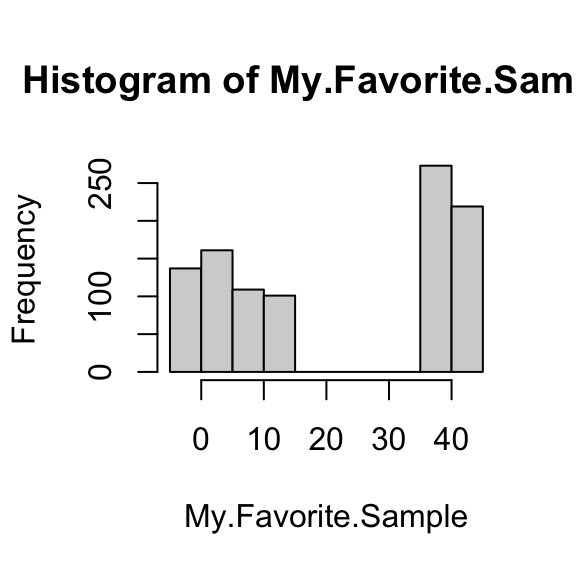

```
   Min. 1st Qu.  Median    Mean 3rd Qu.    Max.
 -2.583   1.067  10.566  21.754  39.824  42.816
```

#### Hmm…

- Is it strange to see “two bumps” in the histogram instead of one, as usual?
- Maybe the sample size is too small, we need to simulate more data?

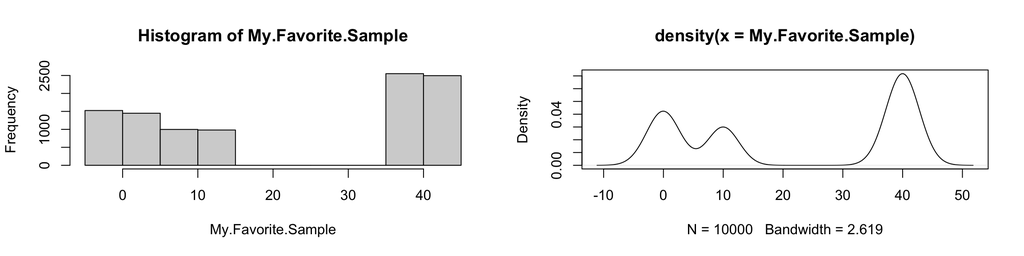

#### AhaMoment!

What do you see?

- This data is *not* being drawn from anything like a normal distribution.
- Consequently, knowing simply the mean and the variance … is not enough to understand the data, that is, the data-generating mechanism behind it.

# … Wait, what was that?!

# License

This document is created for Math/Stat 561, Spring 2023, at Illinois Tech.

While the course materials are generally not to be distributed outside the course without permission of the instructor, all materials posted on this page are licensed under a [Creative Commons Attribution-NonCommercial-ShareAlike 4.0 International License](https://creativecommons.org/licenses/by-nc-sa/4.0/).

[^1]: Sonja Petrović, Associate Professor of Applied Mathematics, College of Computing, Illinios Tech. [Homepage](https://www.SonjaPetrovicStats.com), Email.